# **Multivariate Analysis of Variance (MANOVA) in Binder Jet Printing Data**

This project applies multivariate analysis of variance techniques (MANOVA) to binder jet printing data to identify which of six process parameters and their interactions significantly affect the strength and density of the green parts produced. As this is meant to emulate real laboratory data, the sample size is small (N=60) and the datapoints do not originate from a rational DoE design.

Strictly, as there are no categorical variables in this dataset (i.e. no well-defined groups to analyse variance between), this may better be described as multivariate multiple regression, MMR. The procedure is the same, as the statsmodels package accounts for the lack of categorical variables internally.

MANOVA is applied iteratively to exclude all but the significant terms from the model, an ordinary least squares (OLS) model is then used fit to each dependent variable separately, and the model fit and formulation insights highlighted and visualised.

### 1 | Import Libraries and Data

Libraries for data-handling, statistical modelling, and plotting, and the dataset for this project are imported.

The data contains six process inputs:

- Binder Saturation Percentage (binder_saturation_pct)
- Particle Size Volume Median in μm (particle_size_d50_um)
- Binder Viscosity in cP (binder_viscosity_cp)
- Print Layer Thickness in μm (layer_thickness_um)
- Cure Temperature in °C (cute_temp_c)
- Cure Time in minutes (cure_time_min)

And two outputs:

- Green Part Strength in mPa (green_strength_mpa)
- Print Density Percentage (print_density_pct)

```python
# data-handling
import pandas as pd
import numpy as np
import re
from copy import deepcopy
import random

# models for MANOVA
from statsmodels.multivariate import manova
import statsmodels.formula.api as smf
import statsmodels.api as sm
from sklearn.linear_model import LinearRegression

# visualisation
import matplotlib.pyplot as plt
WEB_COLOR = "#085E57"     ### core colour from my personal webpage, defined for convenience
```

```python
# read data
df = pd.read_csv('data_binder_jetting.csv', index_col='batch_id')

# display first 5 rows to check data read
df.head()
```

| batch_id | binder_saturation_pct | particle_size_d50_um | binder_viscosity_cp | layer_thickness_um | cure_temp_c | cure_time_min | green_strength_mpa | print_density_pct |
| --- | --- | --- | --- | --- | --- | --- | --- | --- |
| BJ-001 | 68.8 | 21.3 | 22.6 | 99 | 164 | 47 | 1.02 | 67.6 |
| BJ-002 | 68.2 | 29.2 | 21.3 | 82 | 156 | 42 | 1.04 | 66.7 |
| BJ-003 | 64.2 | 41.2 | 10.9 | 120 | 158 | 54 | 0.57 | 57.3 |
| BJ-004 | 82.7 | 34.6 | 22.0 | 140 | 197 | 92 | 2.78 | 53.7 |
| BJ-005 | 59.3 | 31.3 | 22.0 | 81 | 157 | 27 | 0.30 | 66.2 |

### 2 | Check Correlation between Dependent and Independent Variables

#### 2.1 | Dependent Variables

Computes and prints the correlation and covariance matrices for the two response variables, `green_strength_mpa` and `print_density_pct`, to check whether the two dependent variables are related enough to justify analysing them jointly in a MANOVA.

The covariance matrix is less diagnostic and simply serves to illustrate the direction of any linear relationship between two variables. It is dependent on the scale of each variable and values do not indicate strength of the interaction clearly. The negative value here indicates that as one value increases, the other tends to decrease. The correlation matrix is a scaled version of covariance and provides a standardised measure indicating direction and strength of a linear relationship. Here it shows only a weak negative correlation (r ≈ −0.19) between the two response variables. This is a little on the low side to rationalise using a multivariate method (rule of thumb is 0.3-0.7). Treating the two dependent variables separately may valid, but while MANOVA/MMR may not be necessary, the analysis is unlikely to be harmed by continuing with the multivariate option.

A representation of the correlation of the two output variables is visualised using linear regression. A very low R² value, ≈0.035, reinforces a lack of correlation and covariance.

```python
# generate correlation and covariance matrices
corr = df[['green_strength_mpa', 'print_density_pct']].corr()          # correlation matrix
cov  = df[['green_strength_mpa', 'print_density_pct']].cov()           # covariance matrix

# display
print(f"Correlation:\n {corr} \n\nCovariance:\n {cov}")
```

```
Correlation:
                     green_strength_mpa  print_density_pct
green_strength_mpa            1.000000          -0.186179
print_density_pct            -0.186179           1.000000

Covariance:
                     green_strength_mpa  print_density_pct
green_strength_mpa            1.040288          -0.736015
print_density_pct            -0.736015          15.023006
```

```
green_strength_mpa vs. print_density_pct, R2 score: 0.03466
```

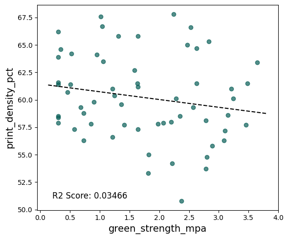

```python
#######################################
#   RUN LINEAR REGRESSION
#######################################

# format data to enable parsing by LinearRegression model
df_gs = df['green_strength_mpa'].to_numpy().reshape(-1,1)
df_pd = df['print_density_pct'].to_numpy().reshape(-1,1)

# run linear regression and get R2 score
lin = LinearRegression().fit(df_gs, df_pd)
lin_r2 = lin.score(df_gs, df_pd)

# print R2 score
print(f"green_strength_mpa vs. print_density_pct, R2 score: {lin_r2:.5f}")



#######################################
#   VISUALISE RESULT
#######################################

# define chart area
fig, ax = plt.subplots(figsize=(6,5))

# plot data
ax.scatter(df['green_strength_mpa'], df['print_density_pct'], c=WEB_COLOR, alpha=0.7)

# plot linear regression model
x1, x2 = ax.get_xlim()
x_range = np.linspace(x1, x2, 50).reshape(-1,1)
y_pred = lin.predict(x_range)

plt.plot(x_range, y_pred, c='black', linestyle='--')

# annotations
ax.set_xlabel('green_strength_mpa', fontsize=14)
ax.set_ylabel('print_density_pct', fontsize=14)
ax.annotate(xy=(0.2, 51), text=f"R2 Score: {lin_r2:.5f}", fontsize=12)

# display
fig.tight_layout()
```

#### 2.2 | Independent Variables

The spread of each dependent variable is plotted to assess the character of each variable. Some (`binder_viscosity_cp` and `layer_thickness_um`) show potential grouping of values, although this may be due to small dataset size in part.

The correlation of each pair of independent variables is then checked. Most of these are low, and therefore of no concern. One pair (`binder_saturation_pct` and `cure_time_min`) has a fairly high correlation (0.84) and so these are likely collinear and one should be removed from the model as it breaks the assumption of predictor independence. Here, cure time is culled.

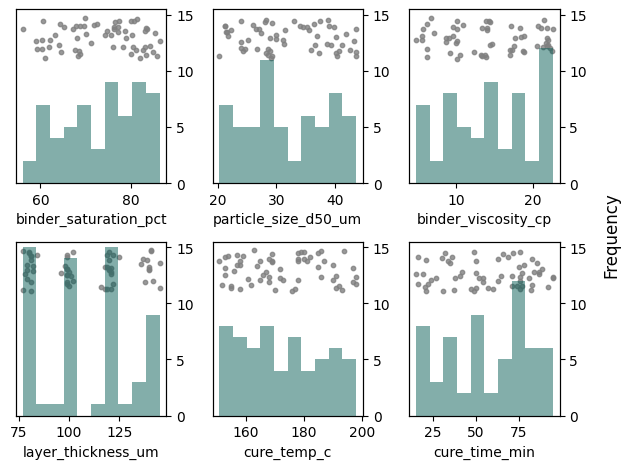

```python
# setup subplots
fig, ax = plt.subplots(2,3)

# define list of column names to be iteratively popped as the code below loops over each axis
cols = list(df.columns)

# loop over each axis
for y in range(0,2,1):
    for x in range(0,3,1):
        # get next column label
        x_label = cols.pop(0)

        # genearte random spread of y-values to ensure scatter plot is read
        ys = [random.random() for x in range(0,len(df))]

        # plot scatter plot of datapoints along a given independent variable to visualise grouping
        ax[y,x].scatter(df[x_label], ys, s=10, alpha=0.8, c='grey', zorder=2)

        # create twin y-axis on right hand side
        ax_yright = ax[y,x].twinx()

        # plot histogram for a given independent variable
        ax_yright.hist(df[x_label], color=WEB_COLOR, alpha=0.5, zorder=1)

        # adjust appearance
        ax[y,x].set_ylim(-3, 1.2)
        ax[y,x].yaxis.set_visible(False)
        ax[y,x].set_xlabel(x_label)
        ax_yright.set_ylim(top=15.5)

# add y-axis label to secondary axis
fig.supylabel("Frequency", x=1)

fig.tight_layout()
```

```python
ivs = ['binder_saturation_pct', 'particle_size_d50_um', 'binder_viscosity_cp',
       'layer_thickness_um', 'cure_temp_c', 'cure_time_min',]  # replace with your actual IV names
print(df[ivs].corr())
```

```
                       binder_saturation_pct  particle_size_d50_um  \
binder_saturation_pct               1.000000             -0.122720
particle_size_d50_um               -0.122720              1.000000
binder_viscosity_cp                 0.080352             -0.115318
layer_thickness_um                  0.169676             -0.108339
cure_temp_c                         0.105249             -0.059539
cure_time_min                       0.844647             -0.059076

                       binder_viscosity_cp  layer_thickness_um  cure_temp_c  \
binder_saturation_pct             0.080352            0.169676     0.105249
particle_size_d50_um             -0.115318           -0.108339    -0.059539
binder_viscosity_cp               1.000000           -0.169913    -0.136502
layer_thickness_um               -0.169913            1.000000     0.015179
cure_temp_c                      -0.136502            0.015179     1.000000
cure_time_min                     0.003356            0.043595     0.195453

                       cure_time_min
binder_saturation_pct       0.844647
particle_size_d50_um       -0.059076
binder_viscosity_cp         0.003356
layer_thickness_um          0.043595
cure_temp_c                 0.195453
cure_time_min               1.000000
```

### 3 | Multivariate Analysis of Variance (MANOVA)

#### 3.1 | Define Variables and MANOVA Experiment

Defines a function, `run_interative_manova()`, which runs a single MANOVA experiment using the statsmodel.multivariate package. The Pillai trace p-value for each term (all independent variables and combinations) is then extracted and the variables and combinations sorted according to p-value.

In order to allow this to run smoothly, lists of dependent, independent, and combinations of variables are first defined manually. This could be improved by automatically generation, but was hard-coded for speed.

```python
#######################################
#   VARIABLES
#######################################

### individual dependent variables
dvs = ['green_strength_mpa','print_density_pct']

### individual independent variables - cure_time_min is commented out as this is collinear with binder_saturation_pct
ivs = [
    'binder_saturation_pct','particle_size_d50_um','binder_viscosity_cp','layer_thickness_um','cure_temp_c', #'cure_time_min',
]

### individual independent variables and all possible combinations  cure_time_min is commented out as this is collinear with binder_saturation_pct
ivs_comb = [
    'binder_saturation_pct','particle_size_d50_um', 'binder_viscosity_cp','layer_thickness_um','cure_temp_c',#'cure_time_min',
    'binder_saturation_pct:particle_size_d50_um','binder_saturation_pct:binder_viscosity_cp','binder_saturation_pct:layer_thickness_um','binder_saturation_pct:cure_temp_c',#'binder_saturation_pct:cure_time_min',
    'particle_size_d50_um:binder_viscosity_cp','particle_size_d50_um:layer_thickness_um','particle_size_d50_um:cure_temp_c',#'particle_size_d50_um:cure_time_min',
    'binder_viscosity_cp:layer_thickness_um','binder_viscosity_cp:cure_temp_c',#'binder_viscosity_cp:cure_time_min',
    'layer_thickness_um:cure_temp_c',#'layer_thickness_um:cure_time_min',
    #'cure_temp_c:cure_time_min',
]
```

```python
def run_iterative_manova(data:pd.DataFrame, dependent_variables:list, independent_variables:list):
    '''
    Runs a single MANOVA experiment.

    Acts as a wrapper for the entire experiment for use in an iterative workflow.

    Returns the formula used and the results in a DataFrame object.
    '''

    # -------------------   MODEL   -------------------

    # define formula for MANOVA (uses the Patsy package that statsmodels is built on)
    formula = " + ".join(dependent_variables) + " ~ " + " + ".join(independent_variables)

    # apply model
    res = manova.MANOVA.from_formula(formula, data=data)#.fit()


    # ----------   COLLECT AND FORMAT DATA   ----------

    # define empty DataFrame object, and populate 'ivs' column with all IVs and combinations used in the experiment
    df_manova = pd.DataFrame(columns=['ivs','main','Pr > F'])
    keys = res.mv_test().results.keys()

    # add to DataFrame
    df_manova['ivs'] = keys

    # populate the 'main' column (indicating whether a main feature or an interaction)
    main_tf = []

    for k in keys:
        # check for a ':' in the feature name (indicates interaction term) and append True/False
        if bool(re.search(':', k)) == True:
            main_tf.append(False)
        else:
            main_tf.append(True)

    # add to DataFrame
    df_manova['main'] = main_tf

    # for each feature, access the statistic table and pull out the p-value (here called: 'Pr > F')
    for index, row in df_manova.iterrows():
        stat_table = res.mv_test().results[row['ivs']]['stat']
        p_val = stat_table.loc["Pillai's trace"]["Pr > F"]

        # add to DataFrame
        df_manova.loc[index, 'Pr > F'] = p_val

    # sort DataFrame according to p=values so that the highest is first, re-index
    df_manova = df_manova.sort_values('Pr > F', ascending=False, ignore_index=True)


    return df_manova, formula
```

#### 3.2 | Run Iterative MANOVA Experiment to Remove Insignificant Features

Runs MANOVA iteractively, eliminating the least significant term on each loop. The procedure is as follows:

- Refits MANOVA using `run_iterative_manova()`, as defined above.
- Drops the term with the highest p-value above 0.05. Interaction terms are removed based only on that criterion. Main effects are not removed on reaching that threshold until all interactions involving that main effect have been dropped.
- Prints a statement indicating what has been removed on each iteration.

```python
flag = False        ### monitors if all insignificant variables have been removed
ivs_removed = []    ### monitors which main features have been removed


while flag == False:
    # run MANOVA experiment
    df_man, formula = run_iterative_manova(df, dvs, ivs_comb)

    # split into main features and interactions
    df_man_main = df_man[df_man["main"] == True]
    df_man_interaction = df_man[df_man["main"] == False]


    #######################################
    #   INTERACTIONS
    #######################################

    # remove interaction with worst p value, if any are above 0.05
    if df_man_interaction.iloc[0]['Pr > F'] > 0.05:
        least_significant = df_man_interaction.iloc[0]['ivs']

        # get index of value in 'ivs_comb' list and pop this
        to_pop = ivs_comb.index(least_significant)
        ivs_comb.pop(to_pop)

        # give user feedback
        print(f"{len(ivs_comb)} FEATURES REMAINING: removed interaction {least_significant}")

    else:
        # if all interactions meet the threshold of p < 0.05, terminate iterative experiment
        flag = True
        print("-------- Resolved --------\n")


    #######################################
    #   MAIN FEATURES
    #######################################

    # check whether each main feature is present in at least one interaction
    present_in_interactions = []     ### collects all IVs present in the interaction features

    # for each interaction, split the two IVs in each interaction and append to 'present_in_interactions'
    for x in ivs_comb:
        if bool(re.search(':', x)) == True:
            x1, x2 = x.split(':')
            present_in_interactions.append(x1)
            present_in_interactions.append(x2)

    # create a dictionary using 'present_in_interactions' to define keys
    # collapses any duplicate values in 'present_in_interactions' into a single key
    present_in_interactions_dict = list(dict.fromkeys(present_in_interactions))

    ivs_copy = deepcopy(ivs)     ### deepcopy variable to break link to original

    # for each main feature present in the interactions, pop this from the list of all main features
    # leaves only those main features present in no interactions
    for iv in present_in_interactions_dict:
        to_pop = ivs_copy.index(iv)
        ivs_copy.pop(to_pop)

    # for each main feature already removed, pop this from the list of all main features too
    # avoids attempts to remove the same feature twice
    for iv in ivs_removed:
        to_pop = ivs_copy.index(iv)
        ivs_copy.pop(to_pop)

    # for any main feature remaining in 'ivs_copy' (:. main features to be removed), remove if insignificant
    for iv in ivs_copy:
        # if main feature p-value above 0.05, get index in 'ivs_comb' and pop
        if df_man_main[df_man_main['ivs'] == iv]['Pr > F'].to_numpy()[0] > 0.05:
            to_pop = ivs_comb.index(iv)
            ivs_comb.pop(to_pop)

            # give user feedback
            print(f"{len(ivs_comb)} FEATURES REMAINING: removed main feature {iv}")

            # monitor main features removed by adding to 'ivs_removed'
            ivs_removed.append(iv)

# display final results and formula
print(formula)

print(df_man)
```

```
14 FEATURES REMAINING: removed interaction binder_viscosity_cp:layer_thickness_um
13 FEATURES REMAINING: removed interaction binder_viscosity_cp:cure_temp_c
12 FEATURES REMAINING: removed interaction layer_thickness_um:cure_temp_c
11 FEATURES REMAINING: removed interaction binder_saturation_pct:cure_temp_c
10 FEATURES REMAINING: removed interaction particle_size_d50_um:binder_viscosity_cp
9 FEATURES REMAINING: removed interaction binder_saturation_pct:layer_thickness_um
8 FEATURES REMAINING: removed interaction particle_size_d50_um:cure_temp_c
-------- Resolved --------

green_strength_mpa + print_density_pct ~ binder_saturation_pct + particle_size_d50_um + binder_viscosity_cp + layer_thickness_um + cure_temp_c + binder_saturation_pct:particle_size_d50_um + binder_saturation_pct:binder_viscosity_cp + particle_size_d50_um:layer_thickness_um
                                          ivs   main    Pr > F
0   binder_saturation_pct:binder_viscosity_cp  False  0.032378
1                         binder_viscosity_cp   True  0.027351
2  binder_saturation_pct:particle_size_d50_um  False  0.015264
3                        particle_size_d50_um   True  0.013572
4     particle_size_d50_um:layer_thickness_um  False  0.007226
5                                 cure_temp_c   True  0.000697
6                       binder_saturation_pct   True  0.000005
7                          layer_thickness_um   True       0.0
8                                   Intercept   True       0.0
```

### 4 | Model and Visualise Results

Defines two plotting functions:

- `plot_main()` draws a scatter plot of one feature (main effect or interaction) against a response (`green_strength_mpa` or `print_density_pct`).
- `plot_interaction()` builds a contour plot over two features by predicting the response from the fitted model when all other terms are given their mean values.

```python
#######################################
#   DEFINE VISUALISATION FUNCTIONS
#######################################

def plot_main(data:pd.DataFrame, feature:str, response:str):
    '''
    Plots a scatter chart of a single main feature against a response.
    '''
    # define chart area
    fig = plt.figure(figsize=(5,4))

    # plot data
    plt.scatter(x=data[feature], y=data[response], alpha=0.7, c=WEB_COLOR)

    # annotate
    plt.xlabel(feature)
    plt.ylabel(response)

    # format
    fig.tight_layout()


def plot_interaction(data:pd.DataFrame, model, feature1:str, feature2:str, response:str, constant_features:list=[]):
    '''
    Plots a contour plot of two features coloured by the response indicating their interation.
    '''
    # define chart area
    fig = plt.figure(figsize=(5,4))

    # define xlims and ylims
    x1, x2 = data[feature1].min(), data[feature1].max(),
    y1, y2 = data[feature2].min(), data[feature2].max(),

    # create sampling grid (25x25)
    x_range = np.linspace(x1, x2, 25)
    y_range = np.linspace(y1, y2, 25)
    X, Y = np.meshgrid(x_range, y_range)

    # create DataFrame indicating IV values at each sampling point
    grid = pd.DataFrame({
        feature1: X.ravel(),
        feature2: Y.ravel(),
    })

    # get mean values for constant features and add to the 'grid' DataFrame
    for ft in constant_features:
        grid[ft] = data[ft].mean()

    # predict the response at each combination of IV values
    Z = model.predict(grid).values.reshape(X.shape)

    # plot data
    plt.contourf(X, Y, Z, levels=50, cmap="viridis")
    plt.colorbar(label=response)

    # annotate
    plt.xlabel(feature1)
    plt.ylabel(feature2)

    # format
    fig.tight_layout()
```

#### 4.1 | Green Part Strength

An ordinary least squares (OLS) linear regression model for `green_strength_mpa` is fitted using the final MANOVA formula.

##### Model Fit

- **R²** indicates the share of the variation in green part strength accounted for by the model. 0.934 indicates that about 93 % of the variance is explained.
- **F Statistic** indicates how the model performs against a model with no predictors. The p-value is more interpretable, with p < 0.05 indicating how likely the fit is no predictor is significant. Our value of p < 0.01 shows at least one predictor has significance.
- **Omnibus** and **Jacque-Bera** test normality of the residuals (leftover errors not explained by the model). Normality is assumed to calculate p-values and confidence intervals for each main effect and interaction, so this ratifies a key assumption used by the MANOVA/MMR analysis. In both cases, a p-value for the test of p < 0.05 indicates a non-normal distribution of residuals. Both values here are around p = 0.25.
- **Skew** tests whether the distribution of residuals is lop-sided, with a perfectly symmetrical distribution affording a value of 0. Large positive values indicate large positive errors or under-predictions, and large negative values show the opposite. The value of -0.5 is acceptable, with over ±1 a threshold for concern.
- **Kurtosis** tests how heavy the tails of residual distribution are, the frequency of extreme errors. A normal distribution would give a value of 3, so our vallue of 2.69 is acceptable.
- **Durbin-Watson** checks for autocorrelation. This is a measure of correlation between a value and the preceeding values. It is included here to check for drift in the variable over time, which could be critical for a case where all experiments had been performed sequentially using the same equipment, for example. Ideal value is 2, so the measured value of 1.812 here is acceptable.
- **Condition Number** checks for multicollinearity, predictors that the model struggles to separate into individual effects. However, it also rises when predictors are on different scales, so the high result here is not a concern. For a more robust treatment, each predictor could be centered and scaled to the same range. Ideal values are below 30.
- The **Q-Q Plot** is used to determine whether or not a set of data follows a normal distribution. It serves as a visual check and reinforcement of the statistical normality tests above. The data fits well to the regression line, indicating normality, with a negative skew, as expected from the skew test.

##### Formulation Insights

Where BS = binder saturation in %, PS = particle size D50 in μm, BV = binder viscosity in cP, LT = layer thickness in μm, and CT = cure temperature in °C.

Three main effects have significant effects on green part strength (using p < 0.05 as a test of significance) assuming all other variables have a constant value:

| Main Effect | Judgement | Coefficient, β | 95% CI | p-value | Comparison with Max. Green Part Strength |
| --- | --- | --- | --- | --- | --- |
| **Binder Saturation** | highly significant positive effect | 0.136 MPa/% | [0.087, 0.186] | p < 0.001 | Equates to a ~4.1 MPa difference over range of binder saturation percentages used (30.2) 112 % of the max. green part strength |
| **Cure temperature** | highly significant positive effect | 0.0095 MPa/°C | [0.004, 0.015] | p = 0.001 | Equates to a ~0.4 MPa difference over range of cure temperatures used (47 °C) 12 % of the max. green part strength |
| **Binder viscosity** | significant negative effect | -0.1601 MPa/% | [-0.285, -0.035] | p = 0.013 | Equates to a ~2.9 MPa difference over range of binder viscosities used (17.8 cP) 78 % of the max. green part strength |
| **Particle size D50** | marginal positive effect | 0.1030 MPa/μm | [-0.005, 0.211] | p = 0.061 | Equates to a ~2.4 MPa difference over range of particle sizes used (23.3 μm) 66 % of the max. green part strength |

Effects of the significant interactions are visualised. Scatter plots are used for main effects, and contour plots for interactions.

```python
#######################################
#   ORDINARY LEAST SQUARES MODELS
#######################################

# fit ordinary least squares (OLS) linear regression model for green strength using same predictor terms as `formula`
strength_model = smf.ols(
    "green_strength_mpa " + re.findall('(?=[~]).*', formula)[0],
    data=df
).fit()

print(f'-------- GREEN STRENGTH MODEL --------\n{strength_model.summary()}\n\n')
```

```
-------- GREEN STRENGTH MODEL --------
                            OLS Regression Results
==============================================================================
Dep. Variable:     green_strength_mpa   R-squared:                       0.934
Model:                            OLS   Adj. R-squared:                  0.924
Method:                 Least Squares   F-statistic:                     90.08
Date:                Mon, 23 Nov 2026   Prob (F-statistic):           2.33e-27
Time:                        14:07:34   Log-Likelihood:                -4.3154
No. Observations:                  60   AIC:                             26.63
Df Residuals:                      51   BIC:                             45.48
Df Model:                           8
Covariance Type:            nonrobust
==============================================================================================================
                                                 coef    std err          t      P>|t|      [0.025      0.975]
--------------------------------------------------------------------------------------------------------------
Intercept                                     -8.1710      2.056     -3.973      0.000     -12.300      -4.042
binder_saturation_pct                          0.1364      0.025      5.526      0.000       0.087       0.186
particle_size_d50_um                           0.1030      0.054      1.918      0.061      -0.005       0.211
binder_viscosity_cp                           -0.1601      0.062     -2.570      0.013      -0.285      -0.035
layer_thickness_um                            -0.0064      0.008     -0.774      0.443      -0.023       0.010
cure_temp_c                                    0.0095      0.003      3.520      0.001       0.004       0.015
binder_saturation_pct:particle_size_d50_um    -0.0017      0.001     -2.590      0.012      -0.003      -0.000
binder_saturation_pct:binder_viscosity_cp      0.0021      0.001      2.421      0.019       0.000       0.004
particle_size_d50_um:layer_thickness_um    -8.111e-05      0.000     -0.323      0.748      -0.001       0.000
==============================================================================
Omnibus:                        2.816   Durbin-Watson:                   1.812
Prob(Omnibus):                  0.245   Jarque-Bera (JB):                2.719
Skew:                          -0.498   Prob(JB):                        0.257
Kurtosis:                       2.690   Cond. No.                     2.50e+05
==============================================================================

Notes:
[1] Standard Errors assume that the covariance matrix of the errors is correctly specified.
[2] The condition number is large, 2.5e+05. This might indicate that there are
strong multicollinearity or other numerical problems.
```

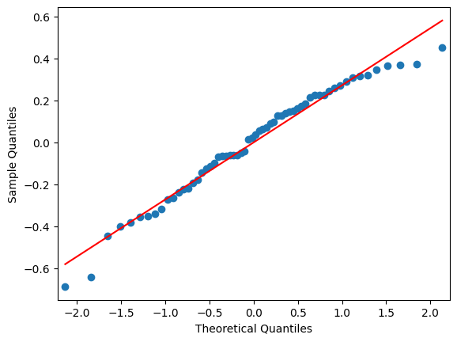

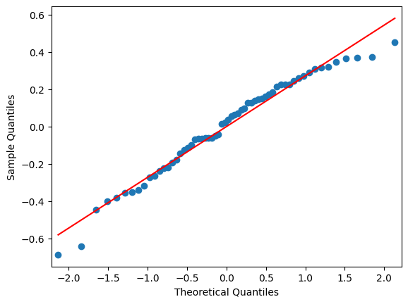

```python
# check Q-Q plot for green strength
residuals = strength_model.resid
fitted = strength_model.fittedvalues

sm.qqplot(residuals, line='r')
```

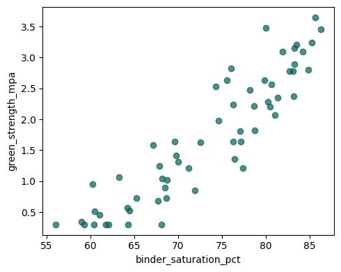

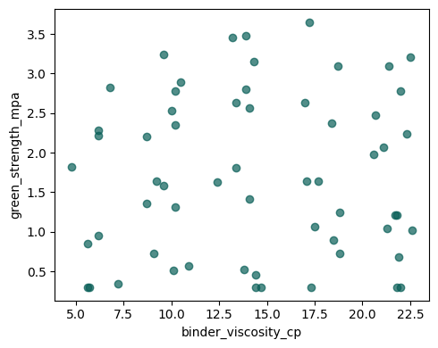

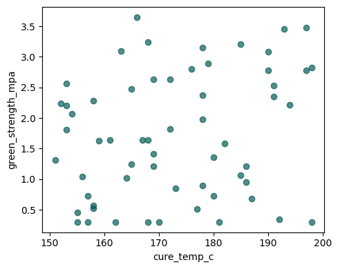

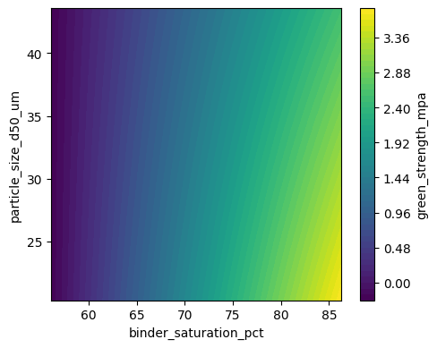

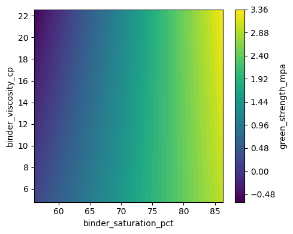

```python
#######################################
#   GREEN STRENGTH VISUALISATIONS
#######################################

# -----------   SIGNIFICANT MAIN FEATURES   -----------

plot_main(
    df, 'binder_saturation_pct', 'green_strength_mpa'
)

plot_main(
    df, 'binder_viscosity_cp', 'green_strength_mpa'
)

plot_main(
    df, 'cure_temp_c', 'green_strength_mpa'
)

# -----------   SIGNIFICANT INTERACTIONS   ------------

plot_interaction(
    df, strength_model,
    'binder_saturation_pct', 'particle_size_d50_um',
    'green_strength_mpa',
    ['binder_viscosity_cp', 'layer_thickness_um', 'cure_temp_c']
)

plot_interaction(
    df, strength_model,
    'binder_saturation_pct', 'binder_viscosity_cp',
    'green_strength_mpa',
    ['particle_size_d50_um', 'layer_thickness_um', 'cure_temp_c']
)
```

#### 4.2 | Print Density Model

Repeats the same procedure for `print_density_pct` as `green_strength_mpa`. Please refer to the text accompanying that model for more in depth explanations.

##### Model Fit

- **R²** of 0.937 indicates that about 94 % of the variance is explained.
- **F Statistic** p-value is < 0.01, indicating at least one predictor has significance.
- **Omnibus** and **Jacque-Bera** show large p-values of 0.832 and 0.763, respectively, indicating a normal distribution of residuals.
- **Skew** of -0.107 is good and indicates only a very slight over-prediction of some values.
- **Kurtosis** of 2.587 is close to the ideal of 3, indicating light tails for the residual distribution.
- **Durbin-Watson** of 2.227 is close to the ideal of 2, indicating minimal autocorrelation.
- **Condition Number** is large, but this is to be expected as predictors are on different scales.
- The **Q-Q Plot** data fits relatively well to the regression line, reinforcing strong normality of the residuals.

##### Formulation Insights

The coefficient values can be plugged into the formula for the MANOVA/MMR model to allow prediction: $$ Print Density (\%) = 102.2169 - 0.0228(BS) - 0.5728(PS) + 0.4211(BV) - 0.2056(LT) - 0.0311(CT) - 0.0019(BS × PS) - 0.0060(BS × BV) + 0.0031(PS × LT) $$

Where BS = binder saturation in %, PS = particle size D50 in μm, BV = binder viscosity in cP, LT = layer thickness in μm, and CT = cure temperature in °C.

| Main Effect | Judgement | Coefficient, β | 95% CI | p-value | Comparison with Range of Print Density % (17 %) |
| --- | --- | --- | --- | --- | --- |
| **Particle Size D50** | significant negative effect | -0.5728 %/μm | [-0.973, -0.172] | p = 0.006 | Equates to a ~13.3 % difference over range of particle sizes used (23.2 μm) 78 % of the print density % range |
| **Layer Thickness** | highly significant negative effect | -0.2056 %/μm | [-0.268, -0.144] | p < 0.001 | Equates to a ~14.0 % difference over range of layer thicknesses used (68.0 μm) 82 % of the print density % range |
| **Cure Temperature** | significant negative effect | -0.0311 %/°C | [-0.051, -0.011] | p = 0.003 | Equates to a ~1.5 % difference over range of cure temperatures used (47 °C) 8 % of the print density % range |

- The interaction between **particle size and layer thickness** (β = 0.0031 %/(μm·μm), 95% CI [0.001, 0.005], p = 0.002) indicates that for every extra 1 μm increase in layer thickness, the benefit of increasing particle size by 1 μm is increased by 0.0031 %. Thicker layers may permit larger particles to pack more densely.
- The interaction between **binder saturation and binder viscosity** (β = -0.0060 %/(%·cP), 95% CI [-0.012, 0.000], p = 0.061) indicates that for every extra 1 cP increase in viscosity, the benefit of increasing binder saturation by 1% is decreased by 0.0060 %. Print density with more viscous binders is reduced with increased saturation, perhaps because more viscous binders introduce greater spacing between particles. This effect is marginally signficant.

Effects of the significant interactions are visualised. Scatter plots are used for main effects, and contour plots for interactions.

```python
#######################################
#   ORDINARY LEAST SQUARES MODELS
#######################################

# fit ordinary least squares (OLS) linear regression model for print density using same predictor terms as `formula`
density_model = smf.ols(
    "print_density_pct " + re.findall('(?=[~]).*', formula)[0],
    data=df
).fit()

print(f'-------- PRINT DENSITY MODEL --------\n{density_model.summary()}\n\n')
```

```
-------- PRINT DENSITY MODEL --------
                            OLS Regression Results
==============================================================================
Dep. Variable:      print_density_pct   R-squared:                       0.937
Model:                            OLS   Adj. R-squared:                  0.927
Method:                 Least Squares   F-statistic:                     94.69
Date:                Mon, 23 Nov 2026   Prob (F-statistic):           7.15e-28
Time:                        14:07:35   Log-Likelihood:                -83.017
No. Observations:                  60   AIC:                             184.0
Df Residuals:                      51   BIC:                             202.9
Df Model:                           8
Covariance Type:            nonrobust
==============================================================================================================
                                                 coef    std err          t      P>|t|      [0.025      0.975]
--------------------------------------------------------------------------------------------------------------
Intercept                                    102.2169      7.635     13.389      0.000      86.890     117.544
binder_saturation_pct                         -0.0228      0.092     -0.248      0.805      -0.207       0.161
particle_size_d50_um                          -0.5728      0.199     -2.873      0.006      -0.973      -0.172
binder_viscosity_cp                            0.4211      0.231      1.820      0.075      -0.043       0.885
layer_thickness_um                            -0.2056      0.031     -6.656      0.000      -0.268      -0.144
cure_temp_c                                   -0.0311      0.010     -3.106      0.003      -0.051      -0.011
binder_saturation_pct:particle_size_d50_um    -0.0019      0.002     -0.802      0.426      -0.007       0.003
binder_saturation_pct:binder_viscosity_cp     -0.0060      0.003     -1.916      0.061      -0.012       0.000
particle_size_d50_um:layer_thickness_um        0.0031      0.001      3.273      0.002       0.001       0.005
==============================================================================
Omnibus:                        0.369   Durbin-Watson:                   2.227
Prob(Omnibus):                  0.832   Jarque-Bera (JB):                0.541
Skew:                          -0.107   Prob(JB):                        0.763
Kurtosis:                       2.587   Cond. No.                     2.50e+05
==============================================================================

Notes:
[1] Standard Errors assume that the covariance matrix of the errors is correctly specified.
[2] The condition number is large, 2.5e+05. This might indicate that there are
strong multicollinearity or other numerical problems.
```

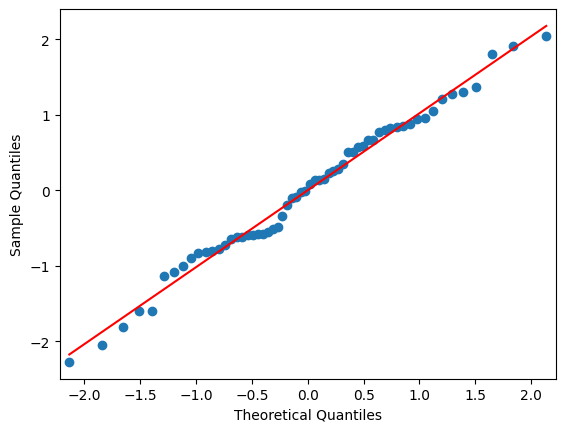

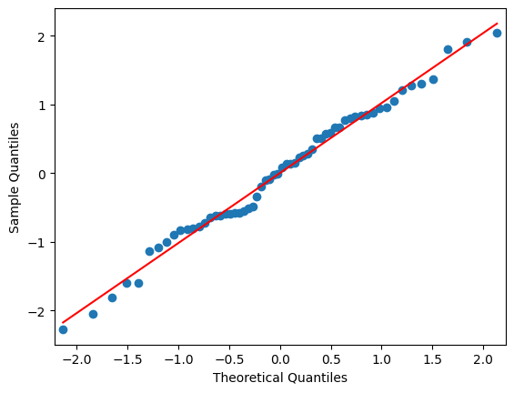

```python
# check Q-Q plot for particle density
residuals = density_model.resid
fitted = density_model.fittedvalues

sm.qqplot(residuals, line='r')
```

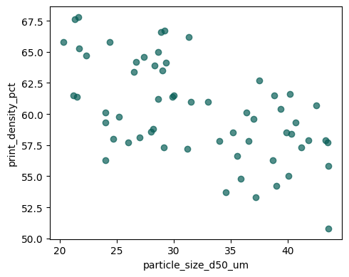

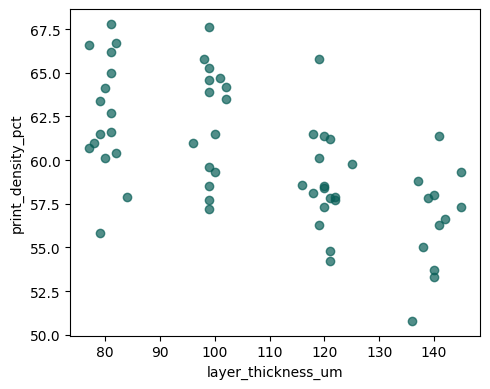

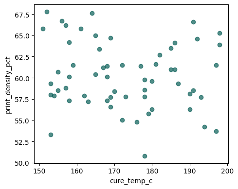

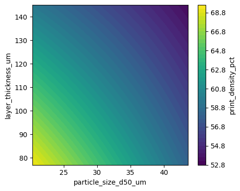

```python
#######################################
#   PRINT DENSITY VISUALISATIONS
#######################################

# -----------   SIGNIFICANT MAIN FEATURES   -----------

plot_main(
    df, 'particle_size_d50_um', 'print_density_pct'
)

plot_main(
    df, 'layer_thickness_um', 'print_density_pct'
)

plot_main(
    df, 'cure_temp_c', 'print_density_pct'
)


# -----------   SIGNIFICANT INTERACTIONS   ------------

plot_interaction(
    df, density_model,
    'particle_size_d50_um', 'layer_thickness_um',
    'print_density_pct',
    ['binder_saturation_pct', 'binder_viscosity_cp', 'cure_temp_c']
)
```

## Selected References

- GeeksforGeeks, Covariance and Coreelation, https://www.geeksforgeeks.org/data-analysis/mathematics-covariance-and-correlation/
- Statology, Q-Q Plots, https://www.statology.org/qq-plot-interpretation/, https://statisticsfundamentals.com/data-visualization/qq-plots/
- GeeksforGeeks, Multicollinearity, https://www.geeksforgeeks.org/machine-learning/multicollinearity-in-regression-analysis/